# Can Statistics Detect Fake Data?

## 6.4 5.4 First-digit chi-square results

The headline table reports both analysis units that matter most: the **latest complete-year cross-section** (independent across countries, $N \approx 200$) and the **pooled country-years** (large $N$, but the same country appears many times, so those p-values are optimistic).

First-digit chi-square goodness-of-fit against Benford’s Law. p_BH is the Benjamini-Hochberg adjusted p-value used for flagging.

| Unit | Indicator | N | X2 | df | p_raw | p_Holm | p_BH | Tier | MAD | Nigrini_band | Cohens_w |
| --- | --- | --- | --- | --- | --- | --- | --- | --- | --- | --- | --- |
| latest year | Land area (sq. km) | 215 | 2.069 | 8 | 0.9788 | 1.0000 | 0.9971 | Reliable | 0.0093 | Acceptable conformity | 0.0981 |
| latest year | Total reserves incl. gold (current USD) | 168 | 8.161 | 8 | 0.4179 | 1.0000 | 0.7530 | Reliable | 0.0193 | Nonconformity | 0.2204 |
| latest year | Exports of goods and services (current USD) | 182 | 9.476 | 8 | 0.3037 | 1.0000 | 0.6420 | Reliable | 0.0226 | Nonconformity | 0.2282 |
| latest year | Imports of goods and services (current USD) | 182 | 3.332 | 8 | 0.9118 | 1.0000 | 0.9971 | Reliable | 0.0123 | Marginal conformity | 0.1353 |
| latest year | GDP (current USD) | 204 | 10.043 | 8 | 0.2620 | 1.0000 | 0.5745 | Reliable | 0.0185 | Nonconformity | 0.2219 |
| latest year | GNI (current USD) | 198 | 8.792 | 8 | 0.3601 | 1.0000 | 0.6897 | Reliable | 0.0179 | Nonconformity | 0.2107 |
| latest year | Life expectancy at birth (years) | 217 | 1070.875 | 8 | 7.46e-226 | 4.51e-223 | 1.87e-224 | Reliable | 0.1769 | Nonconformity | 2.2215 |
| latest year | Fertility rate, total (births per woman) | 217 | 75.525 | 8 | 3.87e-13 | 1.92e-10 | 1.82e-12 | Reliable | 0.0567 | Nonconformity | 0.5900 |
| latest year | Population, total | 217 | 3.942 | 8 | 0.8623 | 1.0000 | 0.9971 | Reliable | 0.0101 | Acceptable conformity | 0.1348 |
| latest year | USASpending current_total_value_of_award (usaspending.csv) | 83980 | 3581.190 | 8 | 0.00e+00 | 0.00e+00 | 0.00e+00 | Reliable | 0.0199 | Nonconformity | 0.2065 |
| latest year | USASpending federal_action_obligation (usaspending.csv) | 77326 | 3774.874 | 8 | 0.00e+00 | 0.00e+00 | 0.00e+00 | Reliable | 0.0213 | Nonconformity | 0.2209 |
| latest year | USASpending potential_total_value_of_award (usaspending.csv) | 84128 | 3415.201 | 8 | 0.00e+00 | 0.00e+00 | 0.00e+00 | Reliable | 0.0195 | Nonconformity | 0.2015 |
| pooled | Land area (sq. km) | 12349 | 111.122 | 8 | 2.24e-20 | 1.13e-17 | 1.12e-19 | Reliable | 0.0086 | Acceptable conformity | 0.0949 |
| pooled | Total reserves incl. gold (current USD) | 9464 | 18.667 | 8 | 0.0167 | 1.0000 | 0.0536 | Reliable | 0.0044 | Close conformity | 0.0444 |
| pooled | Exports of goods and services (current USD) | 9024 | 12.848 | 8 | 0.1172 | 1.0000 | 0.3127 | Reliable | 0.0030 | Close conformity | 0.0377 |
| pooled | Imports of goods and services (current USD) | 9033 | 9.176 | 8 | 0.3277 | 1.0000 | 0.6621 | Reliable | 0.0027 | Close conformity | 0.0319 |
| pooled | GDP (current USD) | 11764 | 6.430 | 8 | 0.5992 | 1.0000 | 0.9392 | Reliable | 0.0017 | Close conformity | 0.0234 |
| pooled | GNI (current USD) | 11234 | 5.749 | 8 | 0.6753 | 1.0000 | 0.9971 | Reliable | 0.0020 | Close conformity | 0.0226 |
| pooled | Life expectancy at birth (years) | 14071 | 43018.187 | 8 | 0.00e+00 | 0.00e+00 | 0.00e+00 | Reliable | 0.1394 | Nonconformity | 1.7485 |
| pooled | Fertility rate, total (births per woman) | 14073 | 2672.421 | 8 | 0.00e+00 | 0.00e+00 | 0.00e+00 | Reliable | 0.0338 | Nonconformity | 0.4358 |
| pooled | Population, total | 14292 | 96.224 | 8 | 2.52e-17 | 1.26e-14 | 1.24e-16 | Reliable | 0.0073 | Acceptable conformity | 0.0821 |
| pooled | USASpending current_total_value_of_award (usaspending.csv) | 110044 | 4409.851 | 8 | 0.00e+00 | 0.00e+00 | 0.00e+00 | Reliable | 0.0194 | Nonconformity | 0.2002 |
| pooled | USASpending federal_action_obligation (usaspending.csv) | 101381 | 4663.333 | 8 | 0.00e+00 | 0.00e+00 | 0.00e+00 | Reliable | 0.0207 | Nonconformity | 0.2145 |
| pooled | USASpending potential_total_value_of_award (usaspending.csv) | 110253 | 4210.003 | 8 | 0.00e+00 | 0.00e+00 | 0.00e+00 | Reliable | 0.0189 | Nonconformity | 0.1954 |

Decision, in the words of the analysis itself:

- **Land area (sq. km)** (pooled): Reject H0 (p = 2.239e-20 < alpha = 0.05): the observed digit distribution differs significantly from Benford’s Law. Every expected count is at least 5 (validity condition satisfied).
- **Total reserves incl. gold (current USD)** (pooled): Reject H0 (p = 0.01675 < alpha = 0.05): the observed digit distribution differs significantly from Benford’s Law. Every expected count is at least 5 (validity condition satisfied).
- **Exports of goods and services (current USD)** (pooled): Fail to reject H0 (p = 0.1172 >= alpha = 0.05): no significant difference from Benford’s Law was detected. Every expected count is at least 5 (validity condition satisfied).
- **Imports of goods and services (current USD)** (pooled): Fail to reject H0 (p = 0.3277 >= alpha = 0.05): no significant difference from Benford’s Law was detected. Every expected count is at least 5 (validity condition satisfied).
- **GDP (current USD)** (pooled): Fail to reject H0 (p = 0.5992 >= alpha = 0.05): no significant difference from Benford’s Law was detected. Every expected count is at least 5 (validity condition satisfied).
- **GNI (current USD)** (pooled): Fail to reject H0 (p = 0.6753 >= alpha = 0.05): no significant difference from Benford’s Law was detected. Every expected count is at least 5 (validity condition satisfied).
- **Life expectancy at birth (years)** (pooled): Reject H0 (p = 0 < alpha = 0.05): the observed digit distribution differs significantly from Benford’s Law. Every expected count is at least 5 (validity condition satisfied).
- **Fertility rate, total (births per woman)** (pooled): Reject H0 (p = 0 < alpha = 0.05): the observed digit distribution differs significantly from Benford’s Law. Every expected count is at least 5 (validity condition satisfied).
- **Population, total** (pooled): Reject H0 (p = 2.519e-17 < alpha = 0.05): the observed digit distribution differs significantly from Benford’s Law. Every expected count is at least 5 (validity condition satisfied).
- **USASpending current_total_value_of_award (usaspending.csv)** (pooled): Reject H0 (p = 0 < alpha = 0.05): the observed digit distribution differs significantly from Benford’s Law. Every expected count is at least 5 (validity condition satisfied).
- **USASpending federal_action_obligation (usaspending.csv)** (pooled): Reject H0 (p = 0 < alpha = 0.05): the observed digit distribution differs significantly from Benford’s Law. Every expected count is at least 5 (validity condition satisfied).
- **USASpending potential_total_value_of_award (usaspending.csv)** (pooled): Reject H0 (p = 0 < alpha = 0.05): the observed digit distribution differs significantly from Benford’s Law. Every expected count is at least 5 (validity condition satisfied).

### 6.4.1 5.4.1 Observed versus expected, per digit

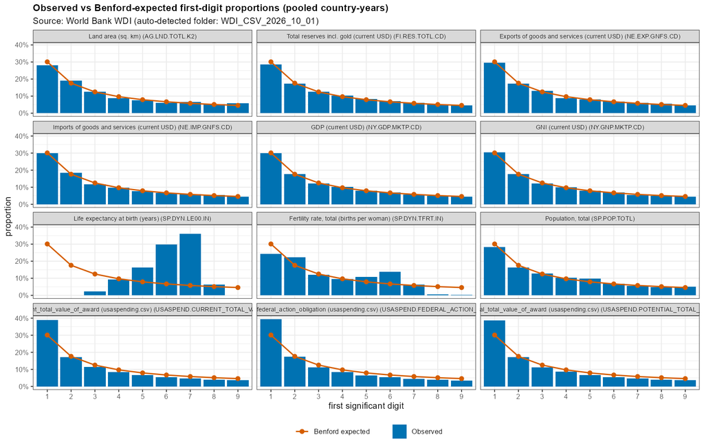

Observed first-digit proportions (bars) against the Benford expected proportions (line and points), pooled country-years.

The numerical version for the first indicator in the table (all indicators are in `outputs/tables/first_digit_frequency.csv`):

Per-digit detail for Land area (sq. km) (pooled country-years).

| Digit | Observed_count | Observed_prop | Expected_prop | Expected_count | Difference | Pearson_residual | Notable |
| --- | --- | --- | --- | --- | --- | --- | --- |
| 1 | 3477 | 0.2816 | 0.3010 | 3717.4 | -0.0195 | -3.943 | yes |
| 2 | 2365 | 0.1915 | 0.1761 | 2174.6 | 0.0154 | 4.084 | yes |
| 3 | 1550 | 0.1255 | 0.1249 | 1542.9 | 0.0006 | 0.182 | no |
| 4 | 1081 | 0.0875 | 0.0969 | 1196.7 | -0.0094 | -3.346 | yes |
| 5 | 932 | 0.0755 | 0.0792 | 977.8 | -0.0037 | -1.465 | no |
| 6 | 753 | 0.0610 | 0.0669 | 826.7 | -0.0060 | -2.564 | yes |
| 7 | 804 | 0.0651 | 0.0580 | 716.1 | 0.0071 | 3.283 | yes |
| 8 | 659 | 0.0534 | 0.0512 | 631.7 | 0.0022 | 1.087 | no |
| 9 | 728 | 0.0590 | 0.0458 | 565.1 | 0.0132 | 6.855 | yes |

Standardised residuals for every indicator, with the $\pm 1.96$ screening lines:

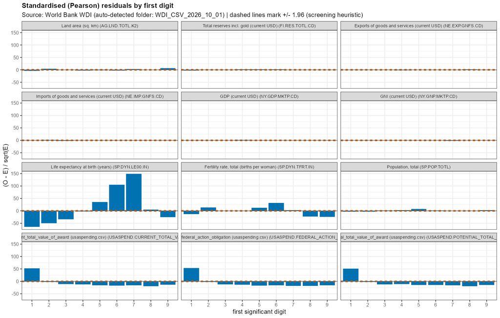

Standardised (Pearson) residuals by first digit. A residual beyond +/-1.96 is a screening heuristic, not a test of fraud.

### 6.4.2 5.4.2 Practical deviation: MAD, Nigrini bands and effect size

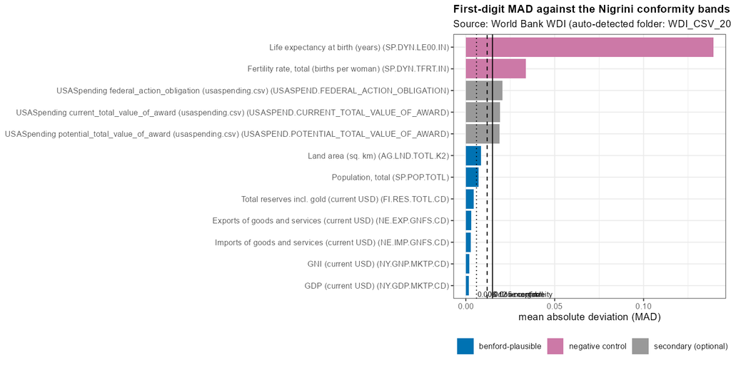

First-digit MAD against the Nigrini conformity bands (pooled country-years). The bands apply to the first digit only.

Practical deviation measures for the pooled country-years. The MAD confidence interval is a non-parametric bootstrap of the pooled values.

| Indicator | MAD | Band | Cohens_w | Flag | MAD_CI |
| --- | --- | --- | --- | --- | --- |
| Land area (sq. km) | 0.0086 | Acceptable conformity | 0.0949 | Statistical deviation: significant AND practically material | [0.0072, 0.0104] |
| Total reserves incl. gold (current USD) | 0.0044 | Close conformity | 0.0444 | No significant deviation detected | [0.0034, 0.0068] |
| Exports of goods and services (current USD) | 0.0030 | Close conformity | 0.0377 | No significant deviation detected | [0.0022, 0.0058] |
| Imports of goods and services (current USD) | 0.0027 | Close conformity | 0.0319 | No significant deviation detected | [0.0022, 0.0055] |
| GDP (current USD) | 0.0017 | Close conformity | 0.0234 | No significant deviation detected | [0.0014, 0.0045] |
| GNI (current USD) | 0.0020 | Close conformity | 0.0226 | No significant deviation detected | [0.0016, 0.0043] |
| Life expectancy at birth (years) | 0.1394 | Nonconformity | 1.7485 | Not assessed - unsuitable data | [0.1383, 0.1405] |
| Fertility rate, total (births per woman) | 0.0338 | Nonconformity | 0.4358 | Not assessed - unsuitable data | [0.0323, 0.0358] |
| Population, total | 0.0073 | Acceptable conformity | 0.0821 | Statistical deviation: significant AND practically material | [0.0056, 0.0092] |
| USASpending current_total_value_of_award (usaspending.csv) | 0.0194 | Nonconformity | 0.2002 | Statistical deviation: significant AND practically material | [0.0188, 0.0200] |
| USASpending federal_action_obligation (usaspending.csv) | 0.0207 | Nonconformity | 0.2145 | Statistical deviation: significant AND practically material | [0.0202, 0.0213] |
| USASpending potential_total_value_of_award (usaspending.csv) | 0.0189 | Nonconformity | 0.1954 | Statistical deviation: significant AND practically material | [0.0183, 0.0195] |

## 6.5 5.5 Anomaly flags and their interpretation

Anomaly flags. Flags are review prompts; a flag is never a statement about fraud.

| Unit | Indicator | N | p_raw | p_BH | Flag |
| --- | --- | --- | --- | --- | --- |
| latest_year | Land area (sq. km) | 215 | 0.9788 | 0.9971 | No significant deviation detected |
| latest_year | Total reserves incl. gold (current USD) | 168 | 0.4179 | 0.7530 | No significant deviation detected |
| latest_year | Exports of goods and services (current USD) | 182 | 0.3037 | 0.6420 | No significant deviation detected |
| latest_year | Imports of goods and services (current USD) | 182 | 0.9118 | 0.9971 | No significant deviation detected |
| latest_year | GDP (current USD) | 204 | 0.2620 | 0.5745 | No significant deviation detected |
| latest_year | GNI (current USD) | 198 | 0.3601 | 0.6897 | No significant deviation detected |
| latest_year | Life expectancy at birth (years) | 217 | 7.46e-226 | 1.87e-224 | Not assessed - unsuitable data |
| latest_year | Fertility rate, total (births per woman) | 217 | 3.87e-13 | 1.82e-12 | Not assessed - unsuitable data |
| latest_year | Population, total | 217 | 0.8623 | 0.9971 | No significant deviation detected |
| latest_year | USASpending current_total_value_of_award (usaspending.csv) | 83980 | 0.00e+00 | 0.00e+00 | Statistical deviation: significant AND practically material |
| latest_year | USASpending federal_action_obligation (usaspending.csv) | 77326 | 0.00e+00 | 0.00e+00 | Statistical deviation: significant AND practically material |
| latest_year | USASpending potential_total_value_of_award (usaspending.csv) | 84128 | 0.00e+00 | 0.00e+00 | Statistical deviation: significant AND practically material |
| pooled | Land area (sq. km) | 12349 | 2.24e-20 | 1.12e-19 | Statistical deviation: significant AND practically material |
| pooled | Total reserves incl. gold (current USD) | 9464 | 0.0167 | 0.0536 | No significant deviation detected |
| pooled | Exports of goods and services (current USD) | 9024 | 0.1172 | 0.3127 | No significant deviation detected |
| pooled | Imports of goods and services (current USD) | 9033 | 0.3277 | 0.6621 | No significant deviation detected |
| pooled | GDP (current USD) | 11764 | 0.5992 | 0.9392 | No significant deviation detected |
| pooled | GNI (current USD) | 11234 | 0.6753 | 0.9971 | No significant deviation detected |
| pooled | Life expectancy at birth (years) | 14071 | 0.00e+00 | 0.00e+00 | Not assessed - unsuitable data |
| pooled | Fertility rate, total (births per woman) | 14073 | 0.00e+00 | 0.00e+00 | Not assessed - unsuitable data |
| pooled | Population, total | 14292 | 2.52e-17 | 1.24e-16 | Statistical deviation: significant AND practically material |
| pooled | USASpending current_total_value_of_award (usaspending.csv) | 110044 | 0.00e+00 | 0.00e+00 | Statistical deviation: significant AND practically material |
| pooled | USASpending federal_action_obligation (usaspending.csv) | 101381 | 0.00e+00 | 0.00e+00 | Statistical deviation: significant AND practically material |
| pooled | USASpending potential_total_value_of_award (usaspending.csv) | 110253 | 0.00e+00 | 0.00e+00 | Statistical deviation: significant AND practically material |